# Analiza próbek krwi pacjentów COVID-19

Data generacji: 06.06.2021r.

Maciej Grabowski

## Spis treści

**1. Wprowadzenie**

- 1.1. Spostrzeżenia
- 1.2. Wykorzystane biblioteki
- 1.3. Użyte wersje bibliotek

**2. Przekształcenia danych**

- 2.1. Dane źródłowe
- 2.2. Zmiana nazw kolumn i formatu danych
- 2.3. Wypełnienie w dół brakujących wartości
- 2.4. Dodanie kolumn obliczeniowych
- 2.5. Zmiana typu danych
- 2.6. Agregacja danych i przygotowanie zbiorów danych

**3. Eksploracja danych**

- 3.1. Analiza wartości atrybutów
- 3.2. Analiza korelacji atrybutów
- 3.3. Wizualizacja danych

**4.Prognozowanie**

- 4.1. Klasyfikacja przypadków
- 4.2. Podział zbioru danych
- 4.3. Uczenie
- 4.4. Predykcja
- 4.5. Optymalizacja parametrów
- 4.6. Wizualizacja - model caret

## 1. Wprowadzenie

Analizie poddano próbki krwi 485 pacjentów z regionu Wuhan w Chinach, aby zidentyfikować znaczące markery ryzyka śmiertelności w wyniku choroby COVID-19.

### 1.1 Spostrzeżenia

Podwyższony wiek, stosunek liczby neutrofili do limfocytów (NLR) wiąże się z wyższą śmiertelnością z powodu COVID-19.

### 1.2 Wykorzystane biblioteki

```r
library(knitr, warn.conflicts = FALSE)
library(tidyr, warn.conflicts = FALSE)
library(dplyr, warn.conflicts = FALSE)
library(lattice, warn.conflicts = FALSE)
library(ggplot2, warn.conflicts = FALSE)
library(plotly, warn.conflicts = FALSE)
library(corrplot, warn.conflicts = FALSE)
library(readxl, warn.conflicts = FALSE)
library(data.table, warn.conflicts = FALSE)
library(caret, warn.conflicts = FALSE)
```

### 1.3 Wersje bibliotek

```r
installed.packages()[names(sessionInfo()$otherPkgs), "Version"]
```

```
##      caret data.table     readxl   corrplot     plotly    ggplot2    lattice
##   "6.0-88"   "1.14.0"    "1.3.1"     "0.88"    "4.9.3"    "3.3.3"  "0.20-44"
##      dplyr      tidyr      knitr
##    "1.0.5"    "1.1.3"     "1.32"
```

## 2. Przekształcenia danych

Dane źródłowe dostarczono w formie pliku Excel (.xlsx). Dane źródłowe wymagają dalszych przekształceń celem poddania analizie. W procesie ETL przewidziano następujące kroki:

- wczytanie danych i przypisanie do zmiennej data.raw
- zmiana nazw kolumn na bardziej czytelne
- operacja “wypełnij w dół” (uzupełnienie danych brakujących - ID pacjent)
- zmiana typu danych (na potrzeby agregacji)
- agreagacja danych
- dodanie kolumny obliczeniowej (obliczenie czasu pobytu pacjenta, NLR)
- filtrowanie (wartości NA,NAN)

### 2.1 Dane źródłowe

**Wczytanie danych i przypisanie do zmiennej raw.data:**

```r
library(readxl) # bibliteka odpowiedzialna za szybkie wczytanie danych z pliku Excel
data.raw <- read_excel(paste0(getwd(),"/wuhan_blood_sample_data_Jan_Feb_2020.xlsx"))
```

**Liczba wierszy i kolumn w zbiorze danych:**

```r
dim(data.raw)
```

```
## [1] 6120   81
```

**Podgląd danych źródłowych:**

```r
library(knitr) # biblioteka odpowiedzialna za renderowanie kodu
kable(head(data.raw[1:2, ]), "pipe",caption = "Tabela 1. Podgląd dwóćh pierwszych wierszy danych źródłowych")
```

| PATIENT_ID | RE_DATE | age | gender | Admission time | Discharge time | outcome | Hypersensitive cardiac troponinI | hemoglobin | Serum chloride | Prothrombin time | procalcitonin | eosinophils(%) | Interleukin 2 receptor | Alkaline phosphatase | albumin | basophil(%) | Interleukin 10 | Total bilirubin | Platelet count | monocytes(%) | antithrombin | Interleukin 8 | indirect bilirubin | Red blood cell distribution width | neutrophils(%) | total protein | Quantification of Treponema pallidum antibodies | Prothrombin activity | HBsAg | … |
| --- | --- | --- | --- | --- | --- | --- | --- | --- | --- | --- | --- | --- | --- | --- | --- | --- | --- | --- | --- | --- | --- | --- | --- | --- | --- | --- | --- | --- | --- | --- |
| 1 | 2020-01-31 01:09:00 | 73 | 1 | 2020-01-30 22:12:47 | 2020-02-17 12:40:09 | 0 | NA | NA | NA | NA | NA | NA | NA | NA | NA | NA | NA | NA | NA | NA | NA | NA | NA | NA | NA | NA | NA | NA | NA | … |
| NA | 2020-01-31 01:25:00 | 73 | 1 | 2020-01-30 22:12:47 | 2020-02-17 12:40:09 | 0 | NA | 136 | NA | NA | NA | 0.6 | NA | NA | NA | 0.3 | NA | NA | 105 | 10.7 | NA | NA | NA | 11.9 | 65.8 | NA | NA | NA | NA | … |

Tabela 1. Podglad dwóch pierwszych wierszy danych zródlowych

### 2.2 Zmiana nazw kolumn i typu danych dla wybranych atrybutów

```r
library(data.table)
setnames(data.raw, old = c('PATIENT_ID','RE_DATE','age','gender','Admission time','Discharge time','outcome'), new = c('ID pacjent','Data pobrania','Wiek','Płeć','Data przyjęcia', 'Data opuszczenia','Śmierć'))
```

**Zmiana formatu daty dla wybranych kolumn**

```r
data.raw$'Data pobrania' = as.Date(format(data.raw$'Data pobrania', "%Y-%m-%d"))
data.raw$'Data przyjęcia' = as.Date(format(data.raw$'Data przyjęcia', "%Y-%m-%d"))
data.raw$'Data opuszczenia' = as.Date(format(data.raw$'Data opuszczenia', "%Y-%m-%d"))
```

### 2.4 Wypełnienie w dół brakujących wartości (ID pacjent)

```r
library(tidyr)
fill(data.raw, "ID pacjent") -> data.raw
```

### 2.5 Doddanie kolumny z informacją o długości pobytu pacjenta

```r
dl_pobytu<-as.integer(round(difftime(data.raw$`Data opuszczenia`,data.raw$`Data przyjęcia`,units = "days"),0))
data.raw<-cbind(data.raw,"Dł.pobytu"=dl_pobytu)
```

### Doddanie kolumny obliczeniowej “Neutrophil to lymphocyte ratio” (NLR)

```r
NLR <-ifelse(data.raw$'lymphocyte count'==0,NA,data.raw$'neutrophils count'/data.raw$'lymphocyte count')
data.raw <- cbind(data.raw,  "NLR"=NLR )
```

### 2.6 Zmiana typu danych

```r
data.raw[,c(1,3,4)]<-sapply(data.raw[,c(1,3,4)],as.integer)
data.raw[,7]<-sapply(data.raw[,7],as.logical)
```

**Lista atrybutów oraz typy danych po przekształceniu:**

```r
class(data.raw)
```

```
## [1] "data.frame"
```

```r
rbind(classe = sapply(data.raw, typeof)) %>%
kable(caption = "Tabela 2. Lista atrybutów oraz typy danych")
```

|  | ID pacjent | Data pobrania | Wiek | Plec | Data przyjecia | Data opuszczenia | Smierc | Hypersensitive cardiac troponinI | hemoglobin | Serum chloride | Prothrombin time | procalcitonin | eosinophils(%) | Interleukin 2 receptor | Alkaline phosphatase | albumin | basophil(%) | Interleukin 10 | Total bilirubin | Platelet count | monocytes(%) | antithrombin | Interleukin 8 | indirect bilirubin | Red blood cell distribution width | neutrophils(%) | total protein | Quantification of Treponema pallidum antibodies | Prothrombin activity | … |
| --- | --- | --- | --- | --- | --- | --- | --- | --- | --- | --- | --- | --- | --- | --- | --- | --- | --- | --- | --- | --- | --- | --- | --- | --- | --- | --- | --- | --- | --- | --- |
| classe | integer | double | integer | integer | double | double | logical | double | double | double | double | double | double | double | double | double | double | double | double | double | double | double | double | double | double | double | double | double | double | … |

Tabela 2. Lista atrybutów oraz typy danych

### 2.7 Agregacja danych

```r
##dane do Wykresu 2
wide_data <- data.raw  %>% group_by(data.raw$'Data opuszczenia') %>% summarise(liczba_smierci=sum(Śmierć==1),liczba_ocalonych=sum(Śmierć==0), NLR=median(NLR,na.rm=TRUE))
colnames(wide_data) <-c("Data opuszczenia","Liczba śmierci","Liczba ocalonych","NLR")

##dane do Wykresu 3

wykres_3a<-data.raw[(data.raw$Śmierć==1),] %>% filter(!is.na(NLR))
wykres_3a <- wykres_3a  %>% group_by(wykres_3a$'Data opuszczenia')  %>% summarise(liczba_smierci=sum(Śmierć==1), NLR=mean(NLR,na.rm=TRUE))
wykres_3a<-cbind(wykres_3a,"Śmierć")
colnames(wykres_3a) <-c("Data opuszczenia","Liczba przypadków","NLR","Grupa")

wykres_3b<-data.raw[(data.raw$Śmierć==0),] %>% filter(!is.na(NLR))
wykres_3b <- wykres_3b  %>% group_by(wykres_3b$'Data opuszczenia')  %>% summarise(liczba_ocalonych=sum(Śmierć==0), NLR=mean(NLR,na.rm=TRUE))
wykres_3b<-cbind(wykres_3b,"Ocalony")
colnames(wykres_3b) <-c("Data opuszczenia","Liczba przypadków","NLR","Grupa")

wykres_3 <- rbind(wykres_3a,wykres_3b)

##dane do Wykresu 4
GroupedByPatientDF <- aggregate(data.raw[, -c(1, 2, 5, 6)], by = list(data.raw$'ID pacjent'), FUN = mean, na.rm = TRUE)  %>% filter('lymphocyte count' != 0)  %>%  arrange('ID pacjent')
GroupedByPatientDF["Śmierć"][GroupedByPatientDF["Śmierć"] == 1] <- "Nie_przezyl"
GroupedByPatientDF["Śmierć"][GroupedByPatientDF["Śmierć"] == 0] <- "Przezyl"
GroupedByPatientDF <- GroupedByPatientDF  %>% filter(!is.nan(NLR))

##dane do klasyfikacji

GroupedByPatientClass <- aggregate(data.raw[, c(1, 3, 7, 39,46,83)], by = list(data.raw$'ID pacjent'), FUN = mean, na.rm = TRUE)  %>% filter('lymphocyte count' != 0)  %>%  arrange('ID pacjent')
GroupedByPatientClass["Śmierć"][GroupedByPatientClass["Śmierć"] == 1] <- "Nie_przezyl"
GroupedByPatientClass["Śmierć"][GroupedByPatientClass["Śmierć"] == 0] <- "Przezyl"
GroupedByPatientClass <- GroupedByPatientClass  %>% filter(!is.nan(NLR))
colnames(GroupedByPatientClass)<-c("Grupa","ID_pacjent","Wiek","Status","lymphocyte_count","neutrophils_count","NLR")
```

## Eksploracja danych

### 3.1 Analiza wartości atrybutów

```r
summary(data.raw$Wiek, na.rm=TRUE)
```

```
##    Min. 1st Qu.  Median    Mean 3rd Qu.    Max.
##   18.00   47.00   62.00   59.44   71.00   95.00
```

```r
summary(data.raw$Dł.pobytu,na.rm=TRUE)
```

```
##    Min. 1st Qu.  Median    Mean 3rd Qu.    Max.
##    0.00    8.00   13.00   13.12   18.00   35.00
```

```r
summary(data.raw$'White blood cell count',na.rm=TRUE)
```

```
##    Min. 1st Qu.  Median    Mean 3rd Qu.    Max.    NA's
##    0.13    4.94    7.72   15.60   12.72 1726.60    4993
```

```r
summary(data.raw$'Red blood cell count',na.rm=TRUE)
```

```
##    Min. 1st Qu.  Median    Mean 3rd Qu.    Max.    NA's
##   0.100   3.680   4.140   9.288   4.650 749.500    4993
```

```r
summary(data.raw$'lymphocyte count',na.rm=TRUE)
```

```
##    Min. 1st Qu.  Median    Mean 3rd Qu.    Max.    NA's
##   0.000   0.460   0.800   1.017   1.310  52.420    5163
```

```r
summary(data.raw$'neutrophils count',na.rm=TRUE)
```

```
##    Min. 1st Qu.  Median    Mean 3rd Qu.    Max.    NA's
##    0.06    3.09    5.85    7.81   10.95   33.88    5163
```

```r
summary(data.raw$'hemoglobin',na.rm=TRUE)
```

```
##    Min. 1st Qu.  Median    Mean 3rd Qu.    Max.    NA's
##     6.4   113.0   125.0   123.1   137.0   178.0    5145
```

```r
summary(data.raw$'Dł.pobytu',na.rm=TRUE)
```

```
##    Min. 1st Qu.  Median    Mean 3rd Qu.    Max.
##    0.00    8.00   13.00   13.12   18.00   35.00
```

```r
summary(data.raw$'NLR',na.rm=TRUE)
```

```
##    Min. 1st Qu.  Median    Mean 3rd Qu.    Max.    NA's
##   0.028   2.627   7.212  16.906  23.483 329.200    5164
```

### 3.2 Analiza korelacji atrybutów

```r
cor(data.raw[,c(3,4,7,9,33,39,41,46,82,83)],use="pairwise.complete.obs") %>% kable()
```

|  | Wiek | Plec | Smierc | hemoglobin | White blood cell count | lymphocyte count | Red blood cell count | neutrophils count | Dl.pobytu | NLR |
| --- | --- | --- | --- | --- | --- | --- | --- | --- | --- | --- |
| Wiek | 1.0000000 | -0.2052294 | 0.5860651 | -0.0230758 | -0.0387996 | -0.1578391 | 0.0565002 | 0.3918315 | -0.2172772 | 0.3661391 |
| Plec | -0.2052294 | 1.0000000 | -0.2571963 | -0.2011964 | 0.0682782 | 0.0405077 | 0.0078606 | -0.2077335 | 0.1054211 | -0.2464104 |
| Smierc | 0.5860651 | -0.2571963 | 1.0000000 | -0.0578862 | -0.0013133 | -0.2262234 | 0.0791299 | 0.6071749 | -0.3249631 | 0.5496257 |
| hemoglobin | -0.0230758 | -0.2011964 | -0.0578862 | 1.0000000 | 0.0114331 | -0.0289736 | 0.4165708 | 0.0344678 | -0.0591825 | -0.0004842 |
| White blood cell count | -0.0387996 | 0.0682782 | -0.0013133 | 0.0114331 | 1.0000000 | 0.3933930 | 0.1460027 | 0.8385966 | 0.0046062 | 0.5198626 |
| lymphocyte count | -0.1578391 | 0.0405077 | -0.2262234 | -0.0289736 | 0.3933930 | 1.0000000 | -0.0109982 | -0.1574604 | -0.0240408 | -0.1907325 |
| Red blood cell count | 0.0565002 | 0.0078606 | 0.0791299 | 0.4165708 | 0.1460027 | -0.0109982 | 1.0000000 | 0.0596735 | -0.0353669 | 0.0159663 |
| neutrophils count | 0.3918315 | -0.2077335 | 0.6071749 | 0.0344678 | 0.8385966 | -0.1574604 | 0.0596735 | 1.0000000 | -0.2190366 | 0.6648097 |
| Dl.pobytu | -0.2172772 | 0.1054211 | -0.3249631 | -0.0591825 | 0.0046062 | -0.0240408 | -0.0353669 | -0.2190366 | 1.0000000 | -0.1814816 |
| NLR | 0.3661391 | -0.2464104 | 0.5496257 | -0.0004842 | 0.5198626 | -0.1907325 | 0.0159663 | 0.6648097 | -0.1814816 | 1.0000000 |

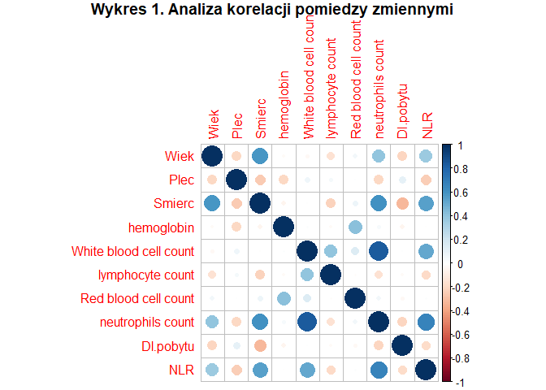

```r
cr<-cor(data.raw[,c(3,4,7,9,33,39,41,46,82,83)],use="pairwise.complete.obs")
corrplot(cr, title="Wykres 1. Analiza korelacji pomiędzy zmiennymi",mar=c(0,0,1,0))
```

### 3.3 Wizualizacja danych

[figure not shown]

```r
library(tidyr)
library(ggplot2)

## Wykres 2 ---------------------------------------------------------------
# utworzenie wartosci dla osi x
wide_data$x <- as.factor(wide_data$'Data opuszczenia')

# Przejscie z układu danych wide do long

data_long <- gather(wide_data, Atrybut, Wartość, -x)
ggplot() +
  # plot bars:
  geom_col(data = subset(data_long, Atrybut==c('Liczba ocalonych','Liczba smierci')),
           mapping = aes(x = x, y = Wartość, fill = Atrybut),
           position = position_dodge()) +

# formatowanie Wykresu
  scale_fill_manual(values = c( "Liczba śmierci" = "red","Liczba ocalonych" = "blue")) +
  theme_minimal() +
  labs(title = "Wykres 2. Łączna liczba przypadków śmiertelnych vs. ocalonych", x = "Data", y = "Liczba pacjentów") +
    theme(plot.title = element_text(size = 16),
        axis.title.x = element_text(size = 12),
        axis.title.y = element_text(size = 12),
        axis.text.x = element_text(angle = 45, hjust = 1))
```

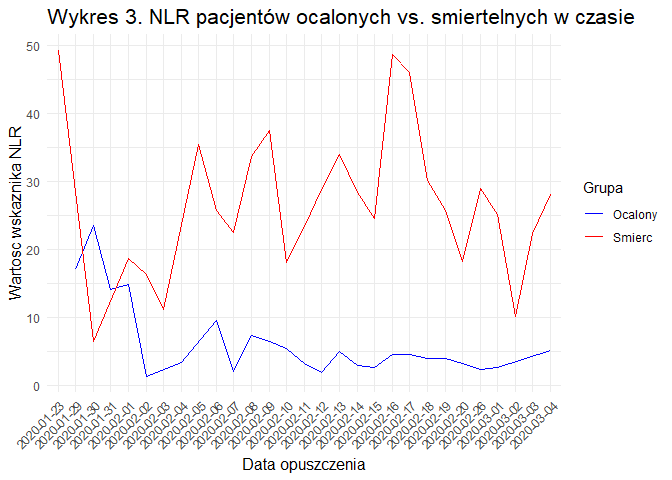

```r
## Wykres 3 ------------------------------------------------------------
wykres_3$'Data opuszczenia' <- factor(wykres_3$'Data opuszczenia')

ggplot(data=wykres_3, aes(x=wykres_3$'Data opuszczenia',y=NLR, group=Grupa)) +
  geom_line(aes(color=Grupa)) + theme_minimal() +
  labs(title = "Wykres 3. NLR pacjentów ocalonych vs. śmiertelnych w czasie", x = "Data opuszczenia", y = "Wartość wskaźnika NLR") +
  scale_color_manual(values = c("#0000FF","#FF0000")) +
  theme(plot.title = element_text(size = 16),
        axis.title.x = element_text(size = 12),
        axis.title.y = element_text(size = 12),
        axis.text.x = element_text(angle = 45, hjust = 1))
```

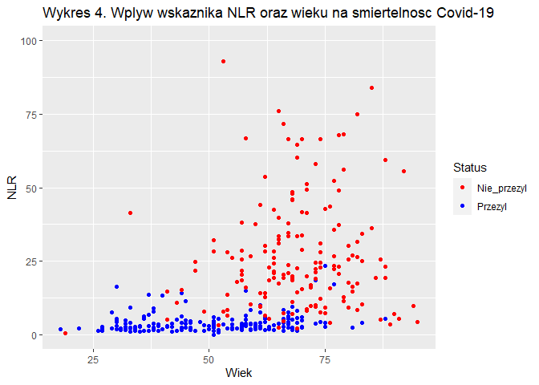

```r
## Wykres 4 ------------------------------------------------------------

ggplot(GroupedByPatientDF, aes(x=Wiek, y=NLR ,col =Śmierć)) + geom_point() +labs(title = "Wykres 4. Wpływ wskaźnika NLR oraz wieku na śmiertelność Covid-19",colour = "Status") + ylim(0, 100) + scale_color_manual(values = c("Przezyl" = '#0000ff','Nie_przezyl' = '#FF0000') )
```

## 4. Klasyfikacja

Celem predykcji jest określenie, czy pacjent przeżyje lub umrze na podstawie wartości wybranych atrybutów, które go cechują.

### 4.1 Podział zbioru danych

```r
library(caret)
set.seed(23)
inTraining <-
    createDataPartition(
        # atrybut do stratyfikacji
        y = GroupedByPatientClass$Status,
        # procent w zbiorze uczącym
        p = .75,
        # chcemy indeksy a nie listę
        list = FALSE)

training <- GroupedByPatientClass[ inTraining,]
testing  <- GroupedByPatientClass[-inTraining,]
```

### 4.2 Schemat uczenia

```r
ctrl <- trainControl(
    # powtórzona ocena krzyżowa
    method = "repeatedcv",
    # liczba podziałów
    number = 2,
    # liczba powtórzeń
    repeats = 5)
```

### 4.3 Uczenie

```r
set.seed(23)
fit <- train(Status ~ .,
             data = training,
             method = "rf",
             trControl = ctrl,
             # Paramter dla algorytmu uczącego
             ntree = 10)
fit
```

```
## Random Forest
##
## 268 samples
##   6 predictor
##   2 classes: 'Nie_przezyl', 'Przezyl'
##
## No pre-processing
## Resampling: Cross-Validated (2 fold, repeated 5 times)
## Summary of sample sizes: 134, 134, 134, 134, 134, 134, ...
## Resampling results across tuning parameters:
##
##   mtry  Accuracy   Kappa
##   2     0.9940299  0.9879874
##   4     0.9947761  0.9894779
##   6     0.9932836  0.9864564
##
## Accuracy was used to select the optimal model using the largest value.
## The final value used for the model was mtry = 4.
```

### 4.4 Predykcja

```r
rfClasses <- predict(fit, newdata = testing)
confusionMatrix(table(rfClasses, testing$Status))
```

```
## Confusion Matrix and Statistics
##
##
## rfClasses     Nie_przezyl Przezyl
##   Nie_przezyl          40       0
##   Przezyl               0      48
##
##                Accuracy : 1
##                  95% CI : (0.9589, 1)
##     No Information Rate : 0.5455
##     P-Value [Acc > NIR] : < 2.2e-16
##
##                   Kappa : 1
##
##  Mcnemar's Test P-Value : NA
##
##             Sensitivity : 1.0000
##             Specificity : 1.0000
##          Pos Pred Value : 1.0000
##          Neg Pred Value : 1.0000
##              Prevalence : 0.4545
##          Detection Rate : 0.4545
##    Detection Prevalence : 0.4545
##       Balanced Accuracy : 1.0000
##
##        'Positive' Class : Nie_przezyl
##
```

### 4.5 Optymalizacja parametrów

```r
rfGrid <- expand.grid(mtry = 10:30)
gridCtrl <- trainControl(
    method = "repeatedcv",
    summaryFunction = twoClassSummary,
    classProbs = TRUE,
    number = 2,
    repeats = 5)
```

```r
set.seed(23)
fitTune <- train(Status ~ .,
             data = training,
             method = "rf",
             metric = "ROC",
             preProc = c("center", "scale"),
             trControl = gridCtrl,
             tuneGrid = rfGrid,
             ntree = 10)
fitTune
```

```
## Random Forest
##
## 268 samples
##   6 predictor
##   2 classes: 'Nie_przezyl', 'Przezyl'
##
## Pre-processing: centered (6), scaled (6)
## Resampling: Cross-Validated (2 fold, repeated 5 times)
## Summary of sample sizes: 134, 134, 134, 134, 134, 134, ...
## Resampling results across tuning parameters:
##
##   mtry  ROC        Sens       Spec
##   10    0.9979452  0.9950820  0.9945205
##   11    0.9971255  0.9950820  0.9945205
##   12    0.9984954  0.9934426  0.9945205
##   13    0.9993151  0.9950820  0.9917808
##   14    0.9991803  0.9950820  0.9931507
##   15    0.9984954  0.9967213  0.9931507
##   16    0.9991803  0.9967213  0.9945205
##   17    0.9963059  0.9934426  0.9945205
##   18    1.0000000  0.9950820  0.9945205
##   19    0.9978105  0.9950820  0.9945205
##   20    0.9993151  0.9934426  0.9931507
##   21    0.9991803  0.9950820  0.9945205
##   22    0.9993151  0.9950820  0.9931507
##   23    0.9984954  0.9950820  0.9945205
##   24    1.0000000  0.9950820  0.9972603
##   25    0.9983607  0.9950820  0.9945205
##   26    0.9969908  0.9950820  0.9931507
##   27    0.9976757  0.9950820  0.9945205
##   28    0.9984954  0.9934426  0.9945205
##   29    0.9993151  0.9950820  0.9931507
##   30    0.9979452  0.9950820  0.9917808
##
## ROC was used to select the optimal model using the largest value.
## The final value used for the model was mtry = 18.
```

### 4.6 Wizualizacja - model caret

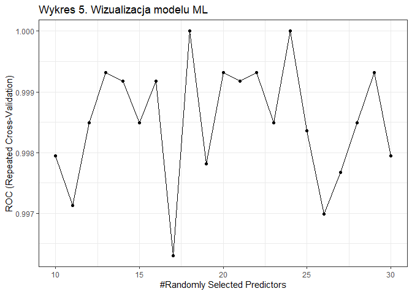

```r
ggplot(fitTune) + theme_bw() + ggtitle("Wykres 5. Wizualizacja modelu ML")
```